# Living by yourself in England’s North West

Antje

6 Oktober 2018

## Introduction: “Living by yourself in England’s North West”

This document shows the outset of analysing the relationship living conditions in the Tees Valley area in the North West of England. It was here that the famous James Cook once set off to his journeys to Australia, where more than hundertthousand people were shipped to later. The area is a formerly heavy-industry place which is now economically rather disadvantaged compared to other parts of the UK, seeking new ways. This inevitably falls back on the population. Here, however, I focus on two things. With an interest in questions of potential loneliness so preeminant among older English people especially, the first section looks at how people in the retirement age are settled.

The second part looks at how it is to be single in Tees Valley, focusing on where there are sex imbalances potentially relevant for dating success. This R Markdown document shows the process.

The dataset stems from the the British national authorities and can be found in its original (quite chaotic) state under: https://data.gov.uk/dataset/cf68804a-fc3b-4036-bd93-1f8b05ed5240/age-by-sex-and-living-arrangements

The Tees Valley consists of the five local authority units (or districts) Darlington, Hartlepool, Middlesbrough, Redcar and Cleveland, and Stockton-on-Tees.

## Being 65+ - Importing the data

Looking at the data from the Tees Valley regions, this needs some manual handling before we can work with it analytically.

```r
#The data was not useful in its original state, as the .csv document was extremely messy and not accordingly formatted. A challenge. Hence, the relevant FIVE (regional) data sets were best to be extracted beforehand manually.
PopTeesH <- read_csv("raw_data/TeesH.csv")
PopTeesS <- read_csv("raw_data/TeesS.csv")
PopTeesM <- read_csv("raw_data/TeesM.csv")
PopTeesR <- read_csv("raw_data/TeesR.csv")
PopTeesD <- read_csv("raw_data/TeesD.csv")

#In preparation to merge the five data sets to one whole we need to make some arrangements, such as relabeling the Variable Names. Each variable receives now a regional designation.
names(PopTeesH) <- paste(names(PopTeesH), sep="_", "H")
names(PopTeesS) <- paste(names(PopTeesS), sep="_", "S")
names(PopTeesM) <- paste(names(PopTeesM), sep="_", "M")
names(PopTeesR) <- paste(names(PopTeesR), sep="_", "R")
names(PopTeesD) <- paste(names(PopTeesD), sep="_", "D")

#Here, we create one common column name to all five data sets, in order to be able to merge them in the next step.
colnames(PopTeesD)[1] <- "Age_Group"
colnames(PopTeesH)[1] <- "Age_Group"
colnames(PopTeesM)[1] <- "Age_Group"
colnames(PopTeesR)[1] <- "Age_Group"
colnames(PopTeesS)[1] <- "Age_Group"

#Merging the five data sets
PopTees2 <- merge(PopTeesD, PopTeesH, by="Age_Group")
PopTees2 <- merge(PopTees2, PopTeesM, by="Age_Group")
PopTees2 <- merge(PopTees2, PopTeesR, by="Age_Group")
PopTees2 <- merge(PopTees2, PopTeesS, by="Age_Group")

#Tidying up the data set and removing some now unncessary files from R Data Section
PopTees3 <- PopTees2[-1, ]
remove(PopTeesD)
remove(PopTeesH)
remove(PopTeesM)
remove(PopTeesS)
remove(PopTeesR)
```

These transformations result in the following data set (a brief sample):

|  | Age_Group | Total_Darlington | Total_InCouple_Darlington | Total_NotCouple_Darlington |
| --- | --- | --- | --- | --- |
| 2 | 16 to 19 | 4517 | 195 | 4322 |
| 3 | 20 to 24 | 4773 | 1452 | 3321 |
| 4 | 25 to 34 | 12837 | 7932 | 4905 |
| 5 | 35 to 39 | 7571 | 5481 | 2090 |
| 6 | 40 to 44 | 7101 | 5249 | 1852 |
| 7 | 45 to 49 | 6475 | 4971 | 1504 |
| 8 | 50 to 54 | 7028 | 5499 | 1529 |
| 9 | 55 to 59 | 5445 | 4294 | 1151 |
| 10 | 60 to 64 | 5085 | 3802 | 1283 |
| 11 | 65 to 69 | 4428 | 3067 | 1361 |
| 12 | 70 to 74 | 4087 | 2431 | 1656 |
| 13 | 75 to 79 | 3503 | 1703 | 1800 |
| 14 | 80 to 84 | 2080 | 758 | 1322 |
| 15 | 85 to 89 | 1047 | 225 | 822 |
| 16 | 90 and over | 412 | 49 | 363 |
| 17 | ALL PEOPLE | 96154 | 47108 | 49046 |

## 65+

Here the data set still presents itself a bit confuse. But let’s now outline that what is of interest - the older population - people from 65 onwards. For this, as this data set is extremely messy I decided to export the file, do a summary calculation for the age group >65 years, and then reimport the file back.

```r
write.xlsx(PopTees3, file = "PopTees3.xlsx", col.names = TRUE, row.names = FALSE)
PT4 <- read.xlsx("PopTees4.xlsx", sheetName = 1)
```

```r
#Selecting Columns and calculating percentage of how many people live in couples, and how many do not
PT5 <- mutate(PT4,
              Living_Alone_D=round(`ALL.PEOPLE...Not.living.in.a.couple_D`/`ALL.PEOPLE...Total.D_D`*100, digits=1))
PT5 <- mutate(PT5,
              Living_Alone_H=round(`ALL.PEOPLE...Not.living.in.a.couple_H`/`ALL.PEOPLE...Total.H_H`*100, digits=1))
PT5 <- mutate(PT5,
              Living_Alone_M=round(`ALL.PEOPLE...Not.living.in.a.couple_M`/`ALL.PEOPLE...Total.M_M`*100, digits=1))
PT5 <- mutate(PT5,
              Living_Alone_R=round(`ALL.PEOPLE...Not.living.in.a.couple_R`/`ALL.PEOPLE...Total.R_R`*100, digits=1))
PT5 <- mutate(PT5,
              Living_Alone_S=round(`ALL.PEOPLE...Not.living.in.a.couple_S`/`ALL.PEOPLE...Total.S_S`*100, digits=1))
```

|  | Living_Alone_D | Living_Alone_H | Living_Alone_M | Living_Alone_R | Living_Alone_S | Age_Group_ |
| --- | --- | --- | --- | --- | --- | --- |
| 1 | 95.7 | 95.4 | 96.7 | 96.3 | 97 | 16 to 19 |
| 2 | 69.6 | 73.5 | 78.6 | 77.3 | 76.3 | 20 to 24 |
| 3 | 38.2 | 38.1 | 44.5 | 40.2 | 37.7 | 25 to 34 |
| 4 | 27.6 | 29.4 | 32 | 26.5 | 25.6 | 35 to 39 |
| 5 | 26.1 | 25.9 | 29.1 | 23.7 | 23.6 | 40 to 44 |
| 6 | 23.2 | 24 | 27.3 | 22.1 | 21.8 | 45 to 49 |
| 7 | 21.8 | 22.7 | 25.9 | 19.8 | 19.8 | 50 to 54 |
| 8 | 21.1 | 22.6 | 25.3 | 19.6 | 19.6 | 55 to 59 |
| 9 | 25.2 | 26.6 | 29 | 23.3 | 24.1 | 60 to 64 |
| 10 | 30.7 | 32.3 | 36.9 | 29.2 | 30.6 | 65 to 69 |

[output cut: 7 more lines]

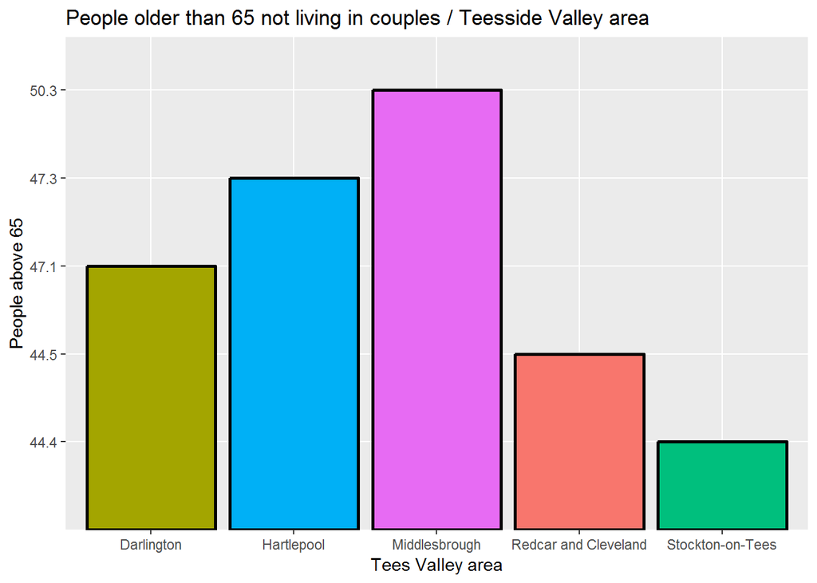

```r
#For a better calculation, I flip the data table - so rows become columns, and vice versa. For this, I have to first select the columns which interest me most - the regional share of people living not in a couple for each area.
#This section does not work properly at the moment, so I need to hide it. It works mostly, but then it suddenly stops and creates a list during the flipping instead of a data table.

PT6 <- as.data.frame(PT5)
PT6 <- PT6[, c(1, 47:51)]
PT7 <- t(PT6)
PT8 <- PT7

# get row and colnames in order
colnames(PT8) = PT8[1, ]
PT8=PT8[-1,]
PT8 <- as.data.frame(PT8)
#Now I create for the bar plot an additional column containing the labelling of the regions.
PT8$Location <- c("Darlington", "Hartlepool", "Middlesbrough", "Redcar and Cleveland", "Stockton-on-Tees")
```

Now, this is interesting, as it becomes clear that Middlesbrough has the highest number of people older than 65 years, who do not live in couple relationships, but maybe on their own, with friends, family members, in shared flats - or with soulmates even, maybe! However, the difference to the other regions is only slightly higher. Maybe differentiating age groups differently yields other results.

## 2) Where are the Teesside Singles?

Let’s again first import the data - the file I worked before with, and a geo-spatial data file.

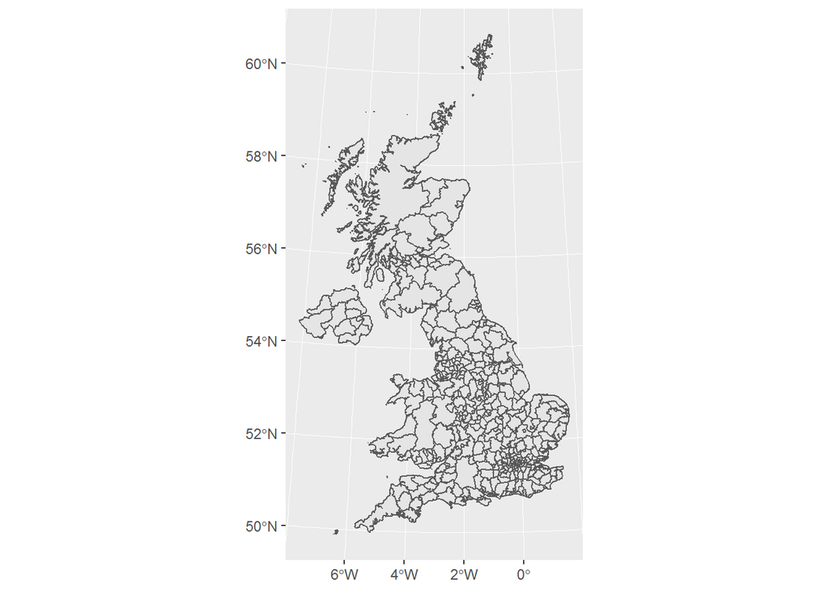

```r
#Selection of the five districts forming the "Tees Valley" region
EngTees <- filter(Eng,
             lad18cd %in% c("E06000002", "E06000001", "E06000003", "E06000004", "E06000005"))
```

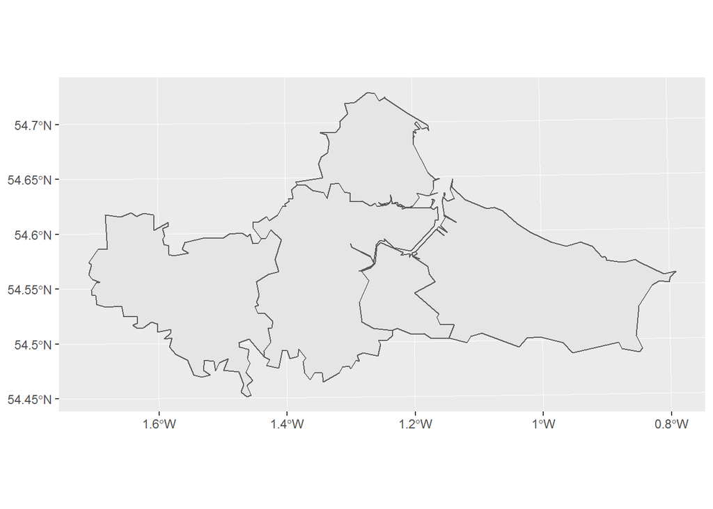

For the second (or data) data set, I use a similar file to before as a base. It has already regrouped some of the original age categories. However, we again need to transform it further before we can work with it:

```r
PopTees4 <- read.xlsx("PopTees3_Altersgruppen.xlsx", sheetName = 1)

#The data set gets flipped soon - this is the code on how to get there.
#Reducing Rows
PopTees5 <- PopTees4[-c(7:19), ]
#colnames(PopTees5)

#Selecting Columns and calculating percentage how many more or less women exist in the age groups for each place
PopTees6 <- select(PopTees5, -starts_with("ALL"))
PopTees6 <- PopTees6[, c(1,4,7,10,13,16,19,22,25,28,31)]
#colnames(PopTees6)
colnames(PopTees6)[2] <- "Male_Single_D"
colnames(PopTees6)[3] <- "Female_Single_D"
colnames(PopTees6)[4] <- "Male_Single_H"
colnames(PopTees6)[5] <- "Female_Single_H"
colnames(PopTees6)[6] <- "Male_Single_M"
colnames(PopTees6)[7] <- "Female_Single_M"
colnames(PopTees6)[8] <- "Male_Single_R"
colnames(PopTees6)[9] <- "Female_Single_R"
colnames(PopTees6)[10] <- "Male_Single_S"
colnames(PopTees6)[11] <- "Female_Single_S"
PopTees6 <- mutate(PopTees6,
        Darlington=round(Female_Single_D/Male_Single_D*100-100, digits=1))
PopTees6 <- mutate(PopTees6,
         Hartlepool=round(Female_Single_H/Male_Single_H*100-100, digits=1))
PopTees6 <- mutate(PopTees6,
         Middlesbrough=round(Female_Single_M/Male_Single_M*100-100, digits=1))
PopTees6 <- mutate(PopTees6,
         Redcar_Cleveland=round(Female_Single_R/Male_Single_R*100-100, digits=1))
PopTees6 <- mutate(PopTees6,
         Stockton=round(Female_Single_S/Male_Single_S*100-100, digits=1))

PopTees7 <- PopTees6[, c(1, 12:16)]

PopTees7<- as.data.frame(PopTees7)

# transpose
TeesPop <- t(PopTees7)


# get row and colnames in order
colnames(TeesPop) = TeesPop[1, ]
TeesPop=TeesPop[-1,]
TeesPop<- as.data.frame(TeesPop)
TeesPop[] <- lapply(TeesPop, function(x) as.numeric(as.character(x)))
TeesPop$lad18nm <- c("Darlington", "Hartlepool", "Middlesbrough", "Redcar and Cleveland", "Stockton-on-Tees")
colnames(TeesPop)[1] <- "20_24"
colnames(TeesPop)[2] <- "25_39"
colnames(TeesPop)[3] <- "40_49"
colnames(TeesPop)[4] <- "50_64"
colnames(TeesPop)[5] <- "65+"
colnames(TeesPop)[6] <- "Average"
#PopT <- PopT[, -6]
```

Now the two data sets get merged:

```r
TeesSingle <- left_join(EngTees, TeesPop, by="lad18nm")
```

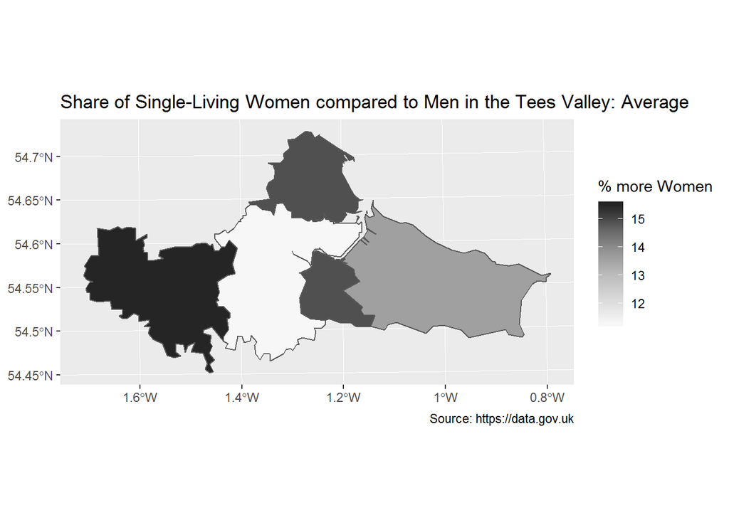

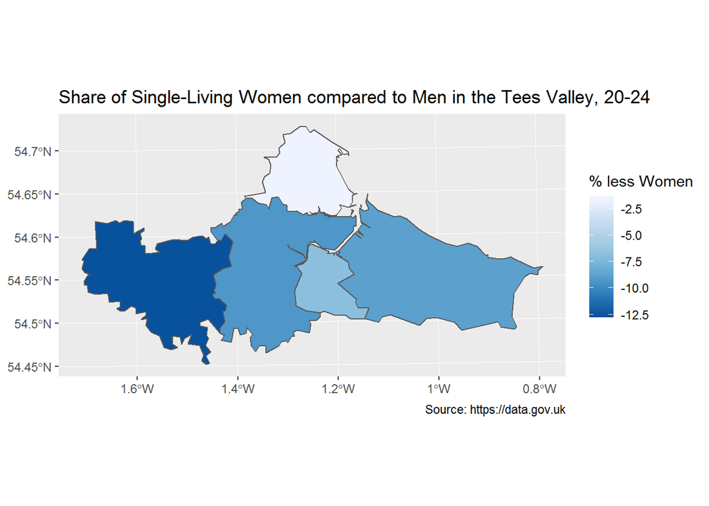

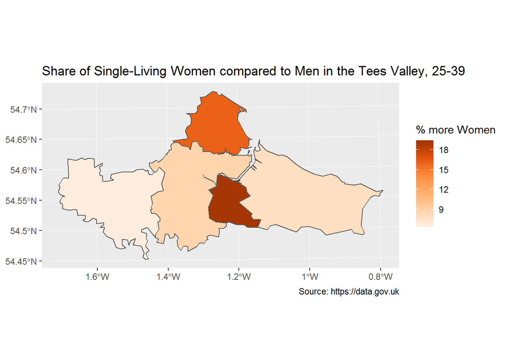

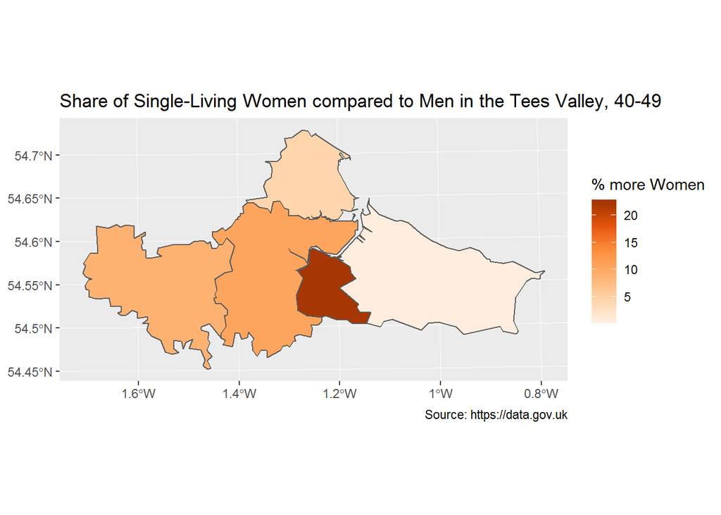

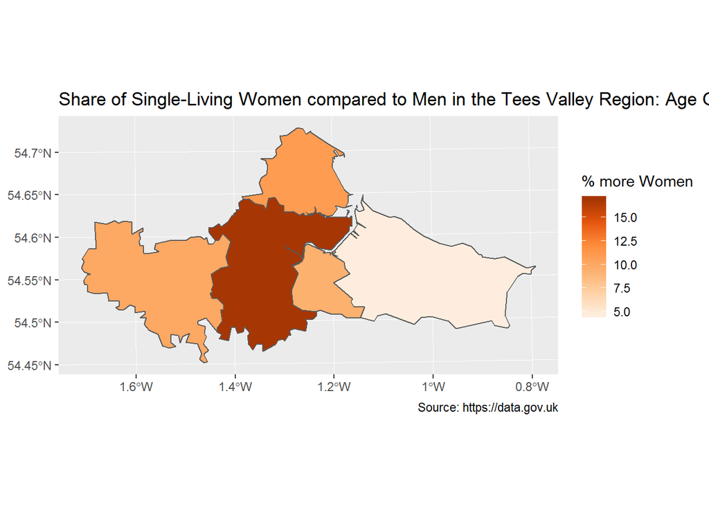

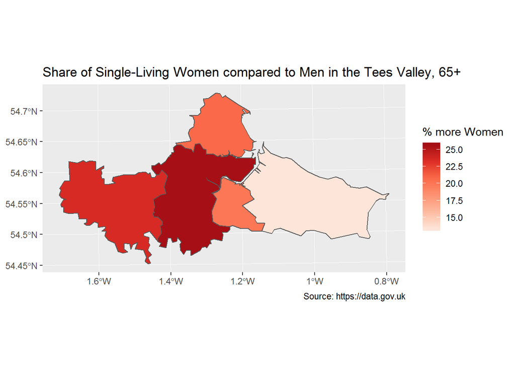